# Kreutz et al. (2022): Analysis of Plasma Binding Measured by GC

Anna Kreutz, Matthew Scott Clifton, W. Matthew Henderson, Marci G. Smeltz, John F. Wambaugh, and Barbara A. Wetmore

2023-04-26

*Please send questions to wambaugh.john@epa.gov*

from “Category-Based Toxicokinetic Evaluations of Data-Poor Per and Polyfluoroalkyl Substances (PFAS) by Gas Chromatography Coupled with Mass Spectrometry”

Anna Kreutz, Matthew Scott Clifton, W. Matthew Henderson, Marci G. Smeltz, John F. Wambaugh, and Barbara A. Wetmore

## Abstract

Concern over per- and polyfluoroalkyl substances (PFAS) has increased significantly as more is learned about their widespread environmental presence, persistence, and bioaccumulative potential. The limited measurement, monitoring, toxicokinetic (TK), and toxicologic data currently available is inadequate to inform risk evaluations across this diverse domain. In this study, 73 PFAS were selected for *in vitro* TK evaluation to expand our knowledge across lesser studied PFAS that include alcohol, amide, and acrylate functional groups. Targeted analytical methods were developed using gas chromatography coupled with tandem mass spectrometry (GC-MS/MS); ultracentrifugation was used to measure human plasma protein binding and human hepatocyte suspensions were used in a substrate depletion approach to measure in vitro clearance (Clint). Method development was successful in plasma for 43 PFAS, with fraction unbound in plasma ($f_{up}$) values ranging from 0.004 for 1,6-dibromododecafluorohexane and 1 for 2-aminohexafluoropropan-2-ol, With a median $f_{up}$ of 0.09 (i.e., 91% bound), these PFAS are highly bound, but exhibit 10-fold lower binding than that recently reported for legacy perfluoroalkyl acids (Smeltz et al., 2022). Physico-chemical property trends analyses revealed that increased binding was associated with increases in mass, van der Waals volumes, and values of Log Pow and Log D at pH 7.4. Thirty of the PFAS evaluated in the hepatocyte assay showed abiotic loss, with many exceeding 60% loss within 60 min of media addition. Metabolic clearance was noted for 11 of the 13 successfully evaluated, with rates up to 49.9 l/min/million cells for 1H,1H,10H,10H-Perfluorodecane-1,10-diol. The Chemical Transformation Simulator revealed potential metabolites and other transformation products to consider during *in vitro* assay data interpretation. This integration of quantitative analytic methods with *in vitro* toxicokinetics has provided critical learnings as New Approach Methods are considered to evaluate PFAS for which volatility, metabolism, and other routes of transformation are likely to modulate their environmental fate.

## HTTK Version

This vignette was created with **httk** v2.3.0. Although we attempt to maintain backward compatibility, if you encounter issues with the latest release of **httk** and cannot easily address the changes, historical versions of httk are available from: https://cran.r-project.org/src/contrib/Archive/httk/

## Prepare for session

```r
knitr::opts_chunk$set(collapse = TRUE, comment = '#>')
options(rmarkdown.html_vignette.check_title = FALSE)
```

### Load the relevant libraries

If you get the message “Error in library(X) : there is no package called ‘X’” then you will need to install that package:

From the R command prompt:

install.packages(“X”)

Or, if using RStudio, look for ‘Install Packages’ under ‘Tools’ tab.

```r
# Clear the memory:
rm(list=ls())
#
#
# Setup
#
#
library(ggplot2)
library(httk)
library(grid)
```

### Multiple plot function

From http://www.cookbook-r.com/Graphs/Multiple_graphs_on_one_page_(ggplot2)/ ggplot objects can be passed in …, or to plotlist (as a list of ggplot objects) - cols: Number of columns in layout - layout: A matrix specifying the layout. If present, ‘cols’ is ignored.

If the layout is something like matrix(c(1,2,3,3), nrow=2, byrow=TRUE), then plot 1 will go in the upper left, 2 will go in the upper right, and 3 will go all the way across the bottom.

```r
multiplot <- function(..., plotlist=NULL, file, cols=1, layout=NULL, heights=NULL, widths=unit(rep_len(1, cols), "null")) {

  # Make a list from the ... arguments and plotlist
  plots <- c(list(...), plotlist)

  numPlots = length(plots)

  # If layout is NULL, then use 'cols' to determine layout
  if (is.null(layout)) {
    # Make the panel
    # ncol: Number of columns of plots
    # nrow: Number of rows needed, calculated from # of cols
    layout <- matrix(seq(1, cols * ceiling(numPlots/cols)),
                    ncol = cols, nrow = ceiling(numPlots/cols))
  }

 if (numPlots==1) {
    print(plots[[1]])

  } else {
    # Set up the page
    grid.newpage()
    if (!is.null(heights))
    {
      pushViewport(viewport(layout = grid.layout(nrow(layout), ncol(layout),heights=heights,widths=widths)))
    } else {
      pushViewport(viewport(layout = grid.layout(nrow(layout), ncol(layout),widths=widths)))
    }
    # Make each plot, in the correct location
    for (i in 1:numPlots) {
      # Get the i,j matrix positions of the regions that contain this subplot
      matchidx <- as.data.frame(which(layout == i, arr.ind = TRUE))

      print(plots[[i]], vp = viewport(layout.pos.row = matchidx$row,
                                      layout.pos.col = matchidx$col))
    }
  }
}
```

### Distribution coefficient

```r
calc_dow <- function(Pow,pH=NA,pKa_Donor=NA,pKa_Accept=NA,fraction_charged=NULL,alpha=0.001)
{
  # Octanol:water distribution coefficient,
  if (is.null(fraction_charged))
  {
    if (is.na(pH)) stop("pH or fraction_charged must be specified in calc_dow.")
    ionization <- calc_ionization(pH=pH,pKa_Donor=pKa_Donor,pKa_Accept=pKa_Accept)
    fraction_charged  <- ionization[["fraction_charged"]]
  }

  Dow <- Pow*(1 + (alpha - 1)*fraction_charged)
  return(Dow)
}
```

# Analysis of Kreutz et al. (2022) $f_{up}$ data

Create a subset of httk data where we know $f_{up}$. We drop the $f_{up}$ measurements of “0” since those are < limit of detection in earlier studies ( [Wetmore, 2012](https://doi.org/10.1093/toxsci/kfr254), [Wetmore, 2015](https://doi.org/10.1093/toxsci/kfv171)). We don’t have quantitative values for analysis of thsoe chemicals.

```r
fup.subset <- subset(chem.physical_and_invitro.data,
                     !is.na(Human.Funbound.plasma))
fup.subset <- subset(fup.subset, Human.Funbound.plasma != "0")
fup.subset$Human.Funbound.plasma <- sapply(
  fup.subset$Human.Funbound.plasma, function(x)
    as.numeric(strsplit(x,",")[[1]][1]))
fup.subset <- subset(fup.subset, Human.Funbound.plasma < 1)
```

Calculate Log D in plasma (pH=7.4)

```r
fup.subset$logD74 <- apply(fup.subset, 1, function(x) log10(calc_dow(
  Pow=10^as.numeric(x[["logP"]]),
  pKa_Accept = x[["pKa_Accept"]],
  pKa_Donor = x[["pKa_Donor"]],
  pH = 7.4)))
```

Group the chemicals.

```r
non.pfas <- fup.subset[regexpr("PFAS",
               fup.subset$Chemical.Class)== -1,]
kreutz <- fup.subset[
               !is.na(fup.subset$Human.Funbound.plasma.Reference),]
kreutz <- kreutz[regexpr("Kreutz",
               kreutz$Human.Funbound.plasma.Reference)!=-1,]
pfas <- fup.subset[regexpr("PFAS",
               fup.subset$Chemical.Class)!= -1,]
dim(non.pfas)
```

```
#> [1] 1681   55
```

```r
dim(kreutz)
```

```
#> [1] 52 55
```

```r
dim(pfas)
```

```
#> [1] 123  55
```

Summary statistics for $f_{up}$. Let’s see what the median and lower 2.5% quantiles are for both non-PFAS and PFAS.

```r
median(non.pfas$Human.Funbound.plasma)
```

```
#> [1] 0.11
```

```r
quantile(non.pfas$Human.Funbound.plasma,0.025)
```

```
#>     2.5%
#> 3.85e-08
```

```r
median(pfas$Human.Funbound.plasma)
```

```
#> [1] 0.0168
```

```r
quantile(pfas$Human.Funbound.plasma,0.025)
```

```
#>       2.5%
#> 1.9345e-08
```

```r
median(kreutz$Human.Funbound.plasma)
```

```
#> [1] 0.0922
```

```r
quantile(kreutz$Human.Funbound.plasma,0.025)
```

```
#>        2.5%
#> 5.68425e-09
```

```r
physchem <- rbind(non.pfas,pfas)
physchem$PFAS <- 0
physchem$GCPFAS <- 0
physchem[physchem$DTXSID %in% pfas$DTXSID,"PFAS"] <- 1
physchem[physchem$DTXSID %in% kreutz$DTXSID,"GCPFAS"] <- 1
physchem$PFAS <- factor(physchem$PFAS)
physchem$GCPFAS <- factor(physchem$GCPFAS)
```

## Test for differences between chemical sets

### Dependence on hydrophobicity (log P):

```r
fit.logp <- lm(data=physchem,Human.Funbound.plasma ~ logP*PFAS*GCPFAS)
summary(fit.logp)
```

```
#>
#> Call:
#> lm(formula = Human.Funbound.plasma ~ logP * PFAS * GCPFAS, data = physchem)
#>
#> Residuals:
#>      Min       1Q   Median       3Q      Max
#> -0.93495 -0.15809 -0.05309  0.13826  0.96702
#>
#> Coefficients: (1 not defined because of singularities)
#>                     Estimate Std. Error t value Pr(>|t|)
#> (Intercept)         0.499250   0.009972  50.063  < 2e-16 ***
#> logP               -0.096062   0.003244 -29.614  < 2e-16 ***
#> PFAS1              -0.327908   0.064898  -5.053 4.82e-07 ***
#> GCPFAS1            -0.007604   0.255673  -0.030 0.976278
#> logP:PFAS1          0.065977   0.016962   3.890 0.000104 ***
#> logP:GCPFAS1       -0.082659   0.030682  -2.694 0.007128 **
#> PFAS1:GCPFAS1       0.492283   0.251982   1.954 0.050906 .
#> logP:PFAS1:GCPFAS1        NA         NA      NA       NA
#> ---
#> Signif. codes:  0 '***' 0.001 '**' 0.01 '*' 0.05 '.' 0.1 ' ' 1
#>
#> Residual standard error: 0.245 on 1714 degrees of freedom
#>   (83 observations deleted due to missingness)
#> Multiple R-squared:  0.3554, Adjusted R-squared:  0.3531
#> F-statistic: 157.5 on 6 and 1714 DF,  p-value: < 2.2e-16
```

```r
fit.logp.best <- lm(data=physchem,Human.Funbound.plasma ~ logP*PFAS)
summary(fit.logp.best)
```

```
#>
#> Call:
#> lm(formula = Human.Funbound.plasma ~ logP * PFAS, data = physchem)
#>
#> Residuals:
#>     Min      1Q  Median      3Q     Max
#> -0.9348 -0.1585 -0.0582  0.1432  0.9671
#>
#> Coefficients:
#>              Estimate Std. Error t value Pr(>|t|)
#> (Intercept)  0.499119   0.010035  49.737  < 2e-16 ***
#> logP        -0.096060   0.003265 -29.424  < 2e-16 ***
#> PFAS1       -0.175452   0.054871  -3.198  0.00141 **
#> logP:PFAS1   0.042969   0.014445   2.975  0.00297 **
#> ---
#> Signif. codes:  0 '***' 0.001 '**' 0.01 '*' 0.05 '.' 0.1 ' ' 1
#>
#> Residual standard error: 0.2466 on 1717 degrees of freedom
#>   (83 observations deleted due to missingness)
#> Multiple R-squared:  0.3459, Adjusted R-squared:  0.3448
#> F-statistic: 302.7 on 3 and 1717 DF,  p-value: < 2.2e-16
```

```r
fit.logd <- lm(data=physchem,Human.Funbound.plasma ~ logD74*PFAS*GCPFAS)
summary(fit.logd)
```

```
#>
#> Call:
#> lm(formula = Human.Funbound.plasma ~ logD74 * PFAS * GCPFAS,
#>     data = physchem)
#>
#> Residuals:
#>      Min       1Q   Median       3Q      Max
#> -0.71372 -0.15235 -0.05949  0.14202  0.94814
#>
#> Coefficients: (1 not defined because of singularities)
#>                       Estimate Std. Error t value Pr(>|t|)
#> (Intercept)           0.391677   0.008303  47.170  < 2e-16 ***
#> logD74               -0.071132   0.002931 -24.268  < 2e-16 ***
#> PFAS1                -0.288392   0.051897  -5.557 3.18e-08 ***
#> GCPFAS1               0.083235   0.270165   0.308  0.75805
#> logD74:PFAS1          0.058919   0.014461   4.074 4.83e-05 ***
#> logD74:GCPFAS1       -0.100530   0.030797  -3.264  0.00112 **
#> PFAS1:GCPFAS1         0.469502   0.266845   1.759  0.07868 .
#> logD74:PFAS1:GCPFAS1        NA         NA      NA       NA
#> ---
#> Signif. codes:  0 '***' 0.001 '**' 0.01 '*' 0.05 '.' 0.1 ' ' 1
#>
#> Residual standard error: 0.26 on 1714 degrees of freedom
#>   (83 observations deleted due to missingness)
#> Multiple R-squared:  0.2741, Adjusted R-squared:  0.2716
#> F-statistic: 107.9 on 6 and 1714 DF,  p-value: < 2.2e-16
```

```r
fit.logd.best <- lm(data=physchem,Human.Funbound.plasma ~ logD74*PFAS)
summary(fit.logd.best)
```

```
#>
#> Call:
#> lm(formula = Human.Funbound.plasma ~ logD74 * PFAS, data = physchem)
#>
#> Residuals:
#>      Min       1Q   Median       3Q      Max
#> -0.71371 -0.15315 -0.06441  0.14552  0.94828
#>
#> Coefficients:
#>               Estimate Std. Error t value Pr(>|t|)
#> (Intercept)   0.391602   0.008364  46.820  < 2e-16 ***
#> logD74       -0.071144   0.002953 -24.094  < 2e-16 ***
#> PFAS1        -0.172552   0.046925  -3.677 0.000243 ***
#> logD74:PFAS1  0.045742   0.012862   3.556 0.000386 ***
#> ---
#> Signif. codes:  0 '***' 0.001 '**' 0.01 '*' 0.05 '.' 0.1 ' ' 1
#>
#> Residual standard error: 0.2619 on 1717 degrees of freedom
#>   (83 observations deleted due to missingness)
#> Multiple R-squared:  0.262,  Adjusted R-squared:  0.2607
#> F-statistic: 203.2 on 3 and 1717 DF,  p-value: < 2.2e-16
```

### Dependence on water solubility (logWSol):

```r
fit.logwsol <- lm(data=physchem,Human.Funbound.plasma ~ logWSol*PFAS*GCPFAS)
summary(fit.logwsol)
```

```
#>
#> Call:
#> lm(formula = Human.Funbound.plasma ~ logWSol * PFAS * GCPFAS,
#>     data = physchem)
#>
#> Residuals:
#>      Min       1Q   Median       3Q      Max
#> -0.70967 -0.17700 -0.05596  0.13936  1.01759
#>
#> Coefficients: (1 not defined because of singularities)
#>                        Estimate Std. Error t value Pr(>|t|)
#> (Intercept)            0.596287   0.014054  42.428  < 2e-16 ***
#> logWSol                0.101334   0.003818  26.542  < 2e-16 ***
#> PFAS1                 -0.455505   0.068208  -6.678 3.29e-11 ***
#> GCPFAS1               -0.143802   0.262179  -0.548   0.5834
#> logWSol:PFAS1         -0.077871   0.019621  -3.969 7.53e-05 ***
#> logWSol:GCPFAS1        0.053180   0.029492   1.803   0.0715 .
#> PFAS1:GCPFAS1          0.521950   0.257377   2.028   0.0427 *
#> logWSol:PFAS1:GCPFAS1        NA         NA      NA       NA
#> ---
#> Signif. codes:  0 '***' 0.001 '**' 0.01 '*' 0.05 '.' 0.1 ' ' 1
#>
#> Residual standard error: 0.2516 on 1657 degrees of freedom
#>   (140 observations deleted due to missingness)
#> Multiple R-squared:  0.3145, Adjusted R-squared:  0.312
#> F-statistic: 126.7 on 6 and 1657 DF,  p-value: < 2.2e-16
```

```r
fit.logwsol.best <- lm(data=physchem,Human.Funbound.plasma ~ logWSol*PFAS)
summary(fit.logwsol.best)
```

```
#>
#> Call:
#> lm(formula = Human.Funbound.plasma ~ logWSol * PFAS, data = physchem)
#>
#> Residuals:
#>      Min       1Q   Median       3Q      Max
#> -0.70927 -0.17732 -0.05896  0.14270  1.01759
#>
#> Coefficients:
#>                Estimate Std. Error t value Pr(>|t|)
#> (Intercept)    0.595944   0.014131  42.172  < 2e-16 ***
#> logWSol        0.101284   0.003839  26.380  < 2e-16 ***
#> PFAS1         -0.324708   0.054393  -5.970 2.90e-09 ***
#> logWSol:PFAS1 -0.060267   0.015112  -3.988 6.95e-05 ***
#> ---
#> Signif. codes:  0 '***' 0.001 '**' 0.01 '*' 0.05 '.' 0.1 ' ' 1
#>
#> Residual standard error: 0.253 on 1660 degrees of freedom
#>   (140 observations deleted due to missingness)
#> Multiple R-squared:  0.3053, Adjusted R-squared:  0.3041
#> F-statistic: 243.2 on 3 and 1660 DF,  p-value: < 2.2e-16
```

### Dependence on molecular weight (MW):

```r
fit.mw <- lm(data=physchem,Human.Funbound.plasma ~ MW*PFAS*GCPFAS)
summary(fit.mw)
```

```
#>
#> Call:
#> lm(formula = Human.Funbound.plasma ~ MW * PFAS * GCPFAS, data = physchem)
#>
#> Residuals:
#>     Min      1Q  Median      3Q     Max
#> -0.3016 -0.2401 -0.1313  0.1844  0.8460
#>
#> Coefficients: (1 not defined because of singularities)
#>                    Estimate Std. Error t value Pr(>|t|)
#> (Intercept)       3.117e-01  1.123e-02  27.747  < 2e-16 ***
#> MW               -1.333e-04  2.365e-05  -5.636 2.02e-08 ***
#> PFAS1             1.160e-02  1.129e-01   0.103   0.9182
#> GCPFAS1          -1.172e-01  3.050e-01  -0.384   0.7007
#> MW:PFAS1         -4.999e-04  2.656e-04  -1.882   0.0600 .
#> MW:GCPFAS1       -7.900e-04  4.908e-04  -1.610   0.1077
#> PFAS1:GCPFAS1     5.608e-01  3.240e-01   1.731   0.0837 .
#> MW:PFAS1:GCPFAS1         NA         NA      NA       NA
#> ---
#> Signif. codes:  0 '***' 0.001 '**' 0.01 '*' 0.05 '.' 0.1 ' ' 1
#>
#> Residual standard error: 0.2974 on 1787 degrees of freedom
#>   (10 observations deleted due to missingness)
#> Multiple R-squared:  0.04264,    Adjusted R-squared:  0.03943
#> F-statistic: 13.27 on 6 and 1787 DF,  p-value: 9.43e-15
```

```r
fit.mw.best <- lm(data=physchem,Human.Funbound.plasma ~ MW)
summary(fit.mw.best)
```

```
#>
#> Call:
#> lm(formula = Human.Funbound.plasma ~ MW, data = physchem)
#>
#> Residuals:
#>     Min      1Q  Median      3Q     Max
#> -0.2969 -0.2355 -0.1454  0.1927  0.7963
#>
#> Coefficients:
#>               Estimate Std. Error t value Pr(>|t|)
#> (Intercept)  3.079e-01  1.118e-02  27.543  < 2e-16 ***
#> MW          -1.444e-04  2.374e-05  -6.083 1.44e-09 ***
#> ---
#> Signif. codes:  0 '***' 0.001 '**' 0.01 '*' 0.05 '.' 0.1 ' ' 1
#>
#> Residual standard error: 0.3004 on 1792 degrees of freedom
#>   (10 observations deleted due to missingness)
#> Multiple R-squared:  0.02023,    Adjusted R-squared:  0.01968
#> F-statistic:    37 on 1 and 1792 DF,  p-value: 1.44e-09
```

$f_{up}$ decreases with molecular weight for all chemicals, but there is no statistically significant difference for PFAS.

### Dependence on Henry’s law constant (logHenry):

```r
fit.henry <- lm(data=physchem,Human.Funbound.plasma ~ logHenry*PFAS*GCPFAS)
summary(fit.henry)
```

```
#>
#> Call:
#> lm(formula = Human.Funbound.plasma ~ logHenry * PFAS * GCPFAS,
#>     data = physchem)
#>
#> Residuals:
#>     Min      1Q  Median      3Q     Max
#> -0.3617 -0.2352 -0.1347  0.1900  0.7797
#>
#> Coefficients: (1 not defined because of singularities)
#>                         Estimate Std. Error t value Pr(>|t|)
#> (Intercept)             0.153070   0.028121   5.443 5.99e-08 ***
#> logHenry               -0.013611   0.003275  -4.156 3.40e-05 ***
#> PFAS1                   0.102140   0.111719   0.914   0.3607
#> GCPFAS1                -0.172837   0.317648  -0.544   0.5864
#> logHenry:PFAS1          0.036428   0.012868   2.831   0.0047 **
#> logHenry:GCPFAS1       -0.003120   0.019596  -0.159   0.8735
#> PFAS1:GCPFAS1           0.316537   0.309588   1.022   0.3067
#> logHenry:PFAS1:GCPFAS1        NA         NA      NA       NA
#> ---
#> Signif. codes:  0 '***' 0.001 '**' 0.01 '*' 0.05 '.' 0.1 ' ' 1
#>
#> Residual standard error: 0.3003 on 1707 degrees of freedom
#>   (90 observations deleted due to missingness)
#> Multiple R-squared:  0.0299, Adjusted R-squared:  0.02649
#> F-statistic: 8.768 on 6 and 1707 DF,  p-value: 1.974e-09
```

```r
fit.henry.best <- lm(data=physchem,Human.Funbound.plasma ~ logHenry)
summary(fit.henry.best)
```

```
#>
#> Call:
#> lm(formula = Human.Funbound.plasma ~ logHenry, data = physchem)
#>
#> Residuals:
#>     Min      1Q  Median      3Q     Max
#> -0.3277 -0.2342 -0.1514  0.1969  0.7759
#>
#> Coefficients:
#>              Estimate Std. Error t value Pr(>|t|)
#> (Intercept)  0.174543   0.026749   6.525 8.92e-11 ***
#> logHenry    -0.010020   0.003122  -3.210  0.00135 **
#> ---
#> Signif. codes:  0 '***' 0.001 '**' 0.01 '*' 0.05 '.' 0.1 ' ' 1
#>
#> Residual standard error: 0.3036 on 1712 degrees of freedom
#>   (90 observations deleted due to missingness)
#> Multiple R-squared:  0.005981,   Adjusted R-squared:  0.005401
#> F-statistic:  10.3 on 1 and 1712 DF,  p-value: 0.001354
```

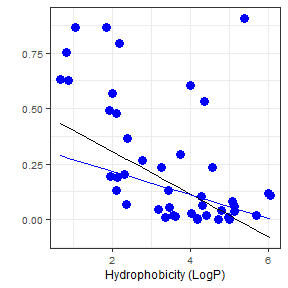

```r
FONT.SIZE <- 9
kreutz$PFAS<-0
kreutz$PFAS <- factor(kreutz$PFAS,levels=c(0,1))
kreutz$logPfit1 <- predict(fit.logp.best,kreutz)
kreutz$PFAS<-1
kreutz$PFAS <- factor(kreutz$PFAS,levels=c(0,1))
kreutz$logPfit2 <- predict(fit.logp.best,kreutz)
fig.logp  <- ggplot(data=kreutz) +
  geom_point(aes(
    x=logP,
    y=Human.Funbound.plasma),
    size=3,
    color="Blue") +
  geom_line(aes(x=logP,y=logPfit1),color="black") +
  geom_line(aes(x=logP,y=logPfit2),color="blue") +
   #ylab("Fraction unbound in plasma") +
  ylab("") +
  xlab("Hydrophobicity (LogP)") +
  theme_bw()  +
  theme( text  = element_text(size=FONT.SIZE))

print(fig.logp)
```

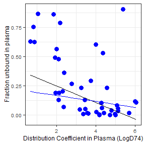

```r
kreutz$PFAS<-0
kreutz$PFAS <- factor(kreutz$PFAS,levels=c(0,1))
kreutz$logDfit1 <- predict(fit.logd.best,kreutz)
kreutz$PFAS<-1
kreutz$PFAS <- factor(kreutz$PFAS,levels=c(0,1))
kreutz$logDfit2 <- predict(fit.logd.best,kreutz)
fig.logd  <- ggplot(data=kreutz) +
  geom_point(aes(
    x=logD74,
    y=Human.Funbound.plasma),
    size=3,
    color="Blue") +
  geom_line(aes(x=logD74,y=logDfit1),color="black") +
  geom_line(aes(x=logD74,y=logDfit2),color="blue") +
  ylab("Fraction unbound in plasma") +
  xlab("Distribution Coefficient in Plasma (LogD74)") +
  theme_bw()  +
  theme( text  = element_text(size=FONT.SIZE))

print(fig.logd)
```

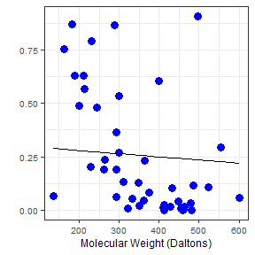

```r
kreutz$PFAS<-0
kreutz$PFAS <- factor(kreutz$PFAS,levels=c(0,1))
kreutz$MWfit <- predict(fit.mw.best,kreutz)
fig.mw <- ggplot(data=kreutz) +
  geom_point(aes(
    x=MW,
    y=Human.Funbound.plasma),
    size=3,
    color="Blue") +
  geom_line(aes(x=MW,y=MWfit),color="black") +
   #ylab("Fraction unbound in plasma") +
  ylab("") +
  xlab("Molecular Weight (Daltons)") +
  theme_bw()  +
  theme( text  = element_text(size=FONT.SIZE))

print(fig.mw)
```

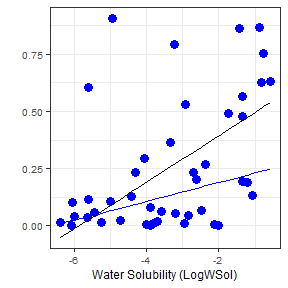

```r
kreutz$PFAS<-0
kreutz$PFAS <- factor(kreutz$PFAS,levels=c(0,1))
kreutz$logWSolfit1 <- predict(fit.logwsol.best,kreutz)
kreutz$PFAS<-1
kreutz$PFAS <- factor(kreutz$PFAS,levels=c(0,1))
kreutz$logWSolfit2 <- predict(fit.logwsol.best,kreutz)
fig.wsol  <- ggplot(data=kreutz) +
  geom_point(aes(
    x=logWSol,
    y=Human.Funbound.plasma),
    size=3,
    color="Blue") +
  geom_line(aes(x=logWSol,y=logWSolfit1),color="black") +
  geom_line(aes(x=logWSol,y=logWSolfit2),color="blue") +
  #ylab("Fraction unbound in plasma") +
  ylab("") +
  xlab("Water Solubility (LogWSol)") +
  theme_bw()  +
  theme( text  = element_text(size=FONT.SIZE))

print(fig.wsol)
```

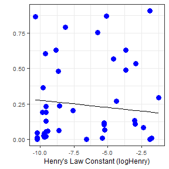

```r
kreutz$PFAS<-0
kreutz$PFAS <- factor(kreutz$PFAS,levels=c(0,1))
kreutz$Henryfit <- predict(fit.henry.best,kreutz)
fig.henry  <- ggplot(data=kreutz) +
  geom_point(aes(
    x=logHenry,
    y=Human.Funbound.plasma),
    size=3,
    color="Blue") +
  geom_line(aes(x=logHenry,y=Henryfit),color="black") +
  #ylab("Fraction unbound in plasma") +
  ylab("") +
  xlab("Henry's Law Constant (logHenry)") +
  theme_bw()  +
  theme( text  = element_text(size=FONT.SIZE))

print(fig.henry)
```

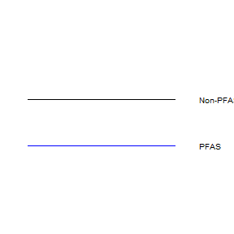

```r
kreutz$Chemical.Class <- sample(c("PFAS","Non-PFAS"),
                                  dim(kreutz)[1],
                                  replace=TRUE)
fig.legend <- ggplot(data=kreutz) +
  geom_line(aes(x=logWSol,y=logWSolfit1,color=Chemical.Class)) +
  #ylab("Fraction unbound in plasma") +
  scale_color_manual(values=c("black","blue"),name = "") +
  ylab("") +
  xlab("") +
    theme_bw()  +
    geom_line(aes(x=logWSol,y=logWSolfit1),color="white",size=3) +
  theme(
    panel.grid = element_blank(),
        axis.title = element_blank(),
        axis.text = element_blank(),
        axis.ticks = element_blank(),
    panel.border = element_blank(),
        panel.background = element_blank())+
   theme(legend.key.height= unit(1.5, 'cm'),
        legend.key.width= unit(6, 'cm'))+
  theme( text  = element_text(size=FONT.SIZE))
print(fig.legend)
```

[figure not shown]

```r
multiplot(fig.logp,fig.logd,fig.mw,fig.wsol,fig.henry,fig.legend,cols=2,widths=c(1.75,1.75))
```